# Lewis Hamilton: The Car or The Driver

Matthew Perlow, Omar Al-za’atreh, Cooper May

May 2

# Research Question:

## “Why has Lewis Hamilton dominated F1 championships throughout the time he has been racing?”

We modified our research question in two ways. One way was to not focus in so much on a specific time period. This will allow us to go farther back in time to see how Lewis Hamilton has progressed through the different levels of racing, maybe not just F1. That way we will be able realize the relationship (or lack thereof) between the types of cars he drives. We also modified the question to not automatically pair Lewis Hamilton’s success with Mercedes. Yes, he is a Mercedes driver but that may or may not be the sole reason for his successes in F1 racing.

## Data Description:

The data was collected using web scraping methodologies that searched publicly available data from a variety of different F1 websites. Unfortunately, the original sources of the data were not documented so the data can not be validated against FIA data.

The F1 data is nevertheless very usable because it has already been pre-processed and updated over 25 times. However, we would like to emphasize the data is not coming from the original data sets and is rather a collection of data from unknown F1 sources. The collector of the data and the Dataset owner is the Kaggle user, Aadil Tajani. Our team has reached out to the author to try and gain additional knowledge on the source of the original data. We will of course provide updates when we ourselves get them.

# Polished Results

## Graph 1

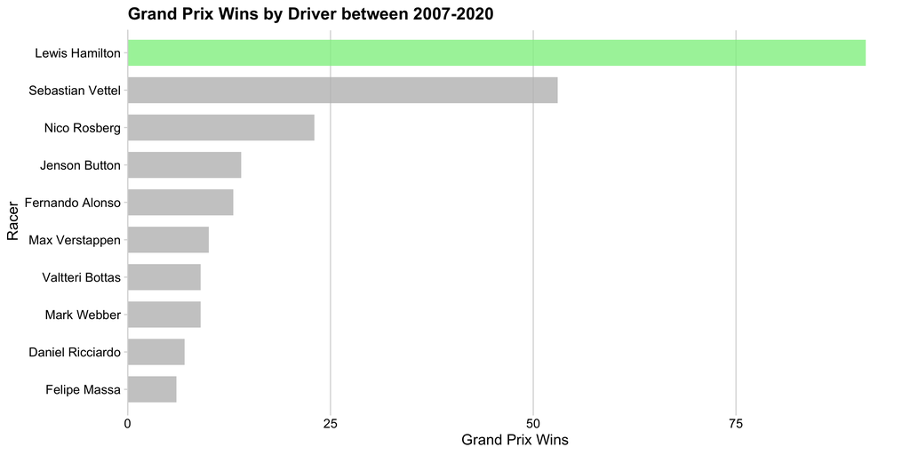

```r
wins <- read_csv("data_raw/race_wins_1950-2020.csv")
#head(wins)

wins_cleaning <- wins %>%
  clean_names() %>%
  mutate(date = dmy(date))

wins_filtering <- wins_cleaning %>%
  filter(year(date) > 2007) %>%
  group_by(name) %>%
  summarise(count = n()) %>%
  arrange(desc(count)) %>%
  slice(1:10) %>%
  mutate(
    is_Lewis = if_else(
      name == 'Lewis Hamilton', TRUE, FALSE)) %>%
  ggplot() +
  geom_col(aes(x = count,
               y = reorder(name, count),
               fill = is_Lewis),
           width = 0.7, alpha = 0.8) +
  scale_x_continuous(
    expand = expansion(mult = c(0, 0.05))) +
  scale_fill_manual(values = c('grey', 'lightgreen')) +
  theme_minimal_vgrid() +
  theme(legend.position = 'none') +
  labs(title = "Grand Prix Wins by Driver between 2007-2020",
       x = "Grand Prix Wins",
       y = "Racer")

wins_filtering
```

As you can see Lewis Hamilton is quite dominant in the sport of F1 driving. He has led the field in Grand Prix wins by a large margin. Another interesting thing to note is that his teammates, who also drive Mercedes cars, are among the top 10 drivers in number of Grand Prix wins. One question we felt was important to dive into was, what really was the reasoning behind Lewis Hamilton’s dominance in the sport of F1. Was it that the car he was driving was far superior than his competitors due to money invested on the Mercedes racing team? Or was Lewis Hamilton that much more skilled than his racing competitors and no matter what he was driving, as long as it was comparative to his rivals, he would come out on top of the leader board. The about of Grand Prix wins are no doubt impressive, however, it does not help us answer why Lewis Hamilton has dominated.

## Graph 2

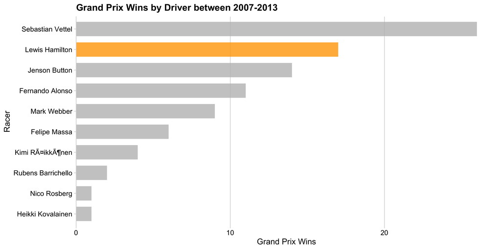

```r
wins_filtering_McLaren <- wins_cleaning %>%
  filter(year(date) > 2007) %>%
  filter(year(date) < 2013) %>%
  group_by(name) %>%
  summarise(count = n()) %>%
  arrange(desc(count)) %>%
  slice(1:10) %>%
  mutate(
    is_Lewis = if_else(
      name == 'Lewis Hamilton', TRUE, FALSE)) %>%
  ggplot() +
  geom_col(aes(x = count,
               y = reorder(name, count),
               fill = is_Lewis),
           width = 0.7, alpha = 0.8) +
  scale_x_continuous(
    expand = expansion(mult = c(0, 0.05))) +
  scale_fill_manual(values = c('grey', 'orange')) +
  theme_minimal_vgrid() +
  theme(legend.position = 'none') +
  labs(title = "Grand Prix Wins by Driver between 2007-2013",
       x = "Grand Prix Wins",
       y = "Racer")

wins_filtering_McLaren
```

Although Hamilton is not the outright leader, he is right there in contention for the most Grand Prix wins throughout his early career with Mclaren, second to Sebastian Vettel. This time frame was earlier in Lewis Hamilton’s career so there are a couple factors that could explain the result above. His inexperience driving in F1, the constructor Mclaren, and the car all could have played a major factor.

To make sure we properly answer the research question, we must look further into his skill as a F1 driver and see how he has performed in qualifying, while also examining variables such as fastest lap speed.

## Graph 3

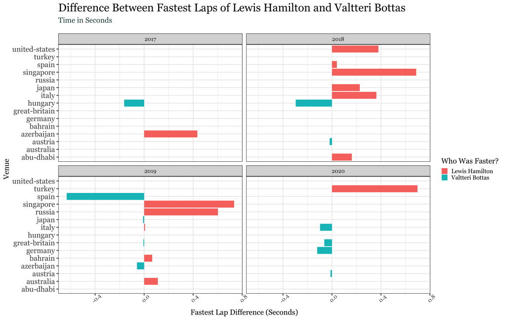

```r
qualifying_times_filtered <- qualifying_times %>%
  filter(Name == c("Lewis Hamilton", "Valtteri Bottas")) %>%
  clean_names()


qualifying_times_filtered$q1 <- as.numeric(seconds(ms(qualifying_times_filtered$q1)))
qualifying_times_filtered$q2 <- as.numeric(seconds(ms(qualifying_times_filtered$q2)))
qualifying_times_filtered$q3 <- as.numeric(seconds(ms(qualifying_times_filtered$q3)))


qualifying_times_filtered <- qualifying_times_filtered %>%
  filter(!is.na(q1)) %>%
  filter(!is.na(q2)) %>%
  filter(!is.na(q3)) %>%
  filter(x < 6040) %>%
  filter(year > 2016) %>%
  group_by(year, venue, name) %>%
  summarise(fastest_qualifying_lap = min(q1,q2,q3)) %>%
  spread(key = name, value = fastest_qualifying_lap) %>%
  clean_names() %>%
  filter(!is.na(lewis_hamilton)) %>%
  filter(!is.na(valtteri_bottas)) %>%
  group_by(year, venue, lewis_hamilton, valtteri_bottas) %>%
  summarise(fastest_lap_difference = valtteri_bottas - lewis_hamilton) %>%
  mutate(
    Driver = if_else(
      fastest_lap_difference > 0, "Lewis Hamilton", "Valtteri Bottas"))



fastest_qualifying_lap_graph <- qualifying_times_filtered %>%
  ggplot(aes(x=factor(venue),y= fastest_lap_difference, fill = Driver)) +
  geom_col()+
  theme(
    axis.text.x = element_text(size=15,angle=45),
    strip.text.x = element_text(size = 15)) + facet_wrap(~year,ncol=2) +
  coord_flip()+
   guides(color = FALSE) +
  theme(
              text = element_text(family = "Georgia"),
              axis.text = element_text(size = 20),
              plot.title = element_text(size = 30, margin = margin(b = 10)),
              plot.subtitle = element_text(size = 20, color = "darkslategrey", margin = margin(b = 25)))+
  labs(title='Difference Between Fastest Laps of Lewis Hamilton and Valtteri Bottas',
       subtitle='Time in Seconds', x = "Venue", y = "Fastest Lap Difference (Seconds)", fill = "Who Was Faster?")

fastest_qualifying_lap_graph
```

To evaluate the performance of Lewis Hamilton in Mercedes, we have to look at his lap times compared with his teammate Valtteri Bottas in Mercedes, because both of them have identical cars. So, any comparison with his teammate would be a fair evaluation of Lewis Hamilton skills. To have bais free results, we evaluated the fastest qualifying round for each driver in races that they both participated in, because in the qualifying rounds no one has the advantage of the pole position in the race. Hamilton and Bottas raced together in Mercedes between the years 2017-2020, so the chart shows the difference between the fastest qualifying lap in these years in all the Grand Prixs between Bottas and Hamilton. The red bars indicate that Hamilton achieved a faster qualifying lap, while a blue bar indicates that Bottas achieved a faster qualifying lap. We can clearly see that Hamilton was very dominant 2018, and slightly better than Bottas in 2019. The graphs from 2017 and 2020 do not have enough races that both participated in, so these results do not produce the strongest argument.

## Graph 4

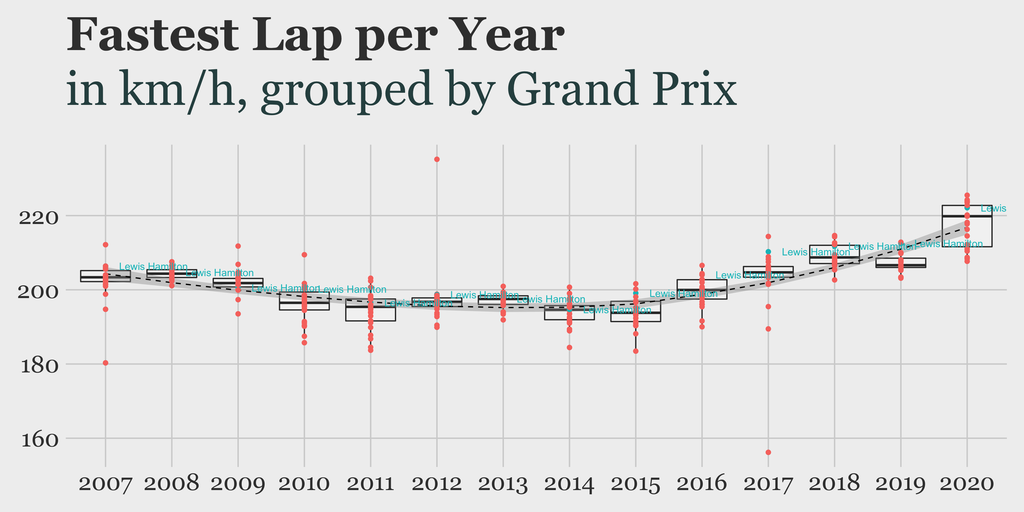

```r
fastest_laps_all_drivers_all_race$Avg.Speed<-as.numeric(fastest_laps_all_drivers_all_race$Avg.Speed)

fastest_lap_times <- fastest_laps_all_drivers_all_race %>%
  mutate(Correct_driver = ifelse(Name  == 'Lewis Hamilton', "Yes", "No")) %>%
  dplyr::filter(Year>2006) %>%
  dplyr::group_by(Name,Year,Correct_driver) %>%
  summarize(medianFastestLapSpeed = median(Avg.Speed,na.rm=T))


label_1 <- fastest_lap_times %>%
        filter(Name == 'Lewis Hamilton') %>%
        arrange(desc(medianFastestLapSpeed))

fastest_lap_times %>%
  ggplot(aes(x=factor(Year), y= medianFastestLapSpeed )) +
  geom_boxplot(alpha=.25) + theme_fivethirtyeight() +
  #geom_jitter(shape=16,position=position_jitter(0.2),size=1.5) +
  geom_smooth(method='loess',aes(group=1),color='black',lty=2,size=.5) +
  geom_point(aes(x=factor(Year), y= medianFastestLapSpeed, color = Correct_driver )) +
  geom_text(data = label_1, aes(label = Name, color = Correct_driver), size = 3, hjust = -.2) +
  labs(title='Fastest Lap per Year',
       subtitle='in km/h, grouped by Grand Prix') +
  guides(color = FALSE) +
  theme(axis.title = element_blank(),
              text = element_text(family = "Georgia"),
              axis.text = element_text(size = 20),
              plot.title = element_text(size = 40, margin = margin(b = 10)),
              plot.subtitle = element_text(size = 40, color = "darkslategrey", margin = margin(b = 25)))
```

```r
fastest_lap <- read_csv(
  here::here("data_raw", "fastest_laps_all_drivers_all_race_1950-2020.csv"),
  col_types = cols(Time = col_character()))
```

```r
fastest_lap <- fastest_lap %>%
  clean_names() %>%
  select(year, venue, name, team, time) %>%
  filter(!is.na(time)) %>%
  mutate(
    time = ms(time), # Converts from character to time period
    seconds = as.numeric(time)) %>% # Converts time period to seconds
  group_by(year, venue) %>%
  mutate(minLapTime = min(seconds)) %>%
  ungroup() %>%
  mutate(secondsBehindLeader = seconds - minLapTime) %>%
  filter(secondsBehindLeader < 5) %>%
  group_by(name) %>%
  mutate(medianSecondsBehindLeader = median(secondsBehindLeader)) %>%
  ungroup() %>%
  arrange(year, venue, minLapTime)
```

```r
#Filtering Lewis Hamilton's McLaren teams race distribution time into their own data set
fastest_lap_2007McLaren <- fastest_lap %>%
    group_by(team) %>%
    filter(team == 'McLaren Mercedes') %>%
    filter(year > 2006) %>%
    filter(year < 2014) %>%
    arrange(medianSecondsBehindLeader)

#Filtering Lewis Hamilton's Mercedes teams race distribution time into their own data set
fastest_lap_2013Mercedes <- fastest_lap %>%
    group_by(team) %>%
    filter(team == 'Mercedes') %>%
    filter(year >= 2013) %>%
    arrange(medianSecondsBehindLeader)
```

We have compared Lewis Hamilton’s driving across many metrics and he is clearly at the top of the competition. The main metric that stands out is the reasoning for how fast he is. His team has been very successful overall because they have more money to invest in Hamilton and the other drivers’ performances. The upcoming visualizations we will use a data set which we have mutated to include a variable titled `secondsBehindLeader`. This variable was calculated by finding the min lap time for each race and subtracting everyones time, which was converted to seconds from this min lap time. If it were a zero that would mean that specific driver had the fastest lap time for that race. This metric shows which racers are consistently REALLY FAST. The faster the driver, the more heavily skewed their distribution of the seconds behind leader variable should be towards zero.

# Viewing a preliminary graph of Hamilton’s fastest lap distribution over his career

To get a sense for how the data set will produce graphs showing the `secondsBehindLeader` variable we will produce a preliminary histogram showing Lewis Hamilton’s career time distribution.

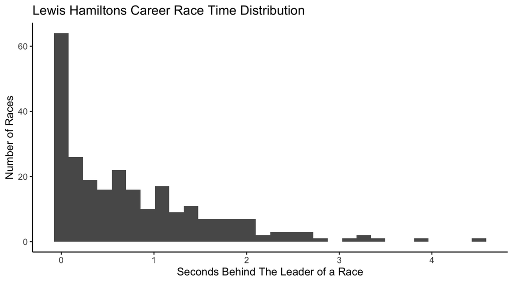

```r
fastest_lap %>%
  filter(name == "Lewis Hamilton") %>%
  ggplot() +
  geom_histogram(aes(x = secondsBehindLeader), bins = 30) +
    labs(title = 'Lewis Hamiltons Career Race Time Distribution',
         x = "Seconds Behind The Leader of a Race",
         y = "Number of Races") +
    theme_classic()
```

Following this hisogram we will compare Lewis with his teammates on both the McLaren and Mercedes racing teams that he has been apart of during his career.

# Viewing Hamiltons race time distribution side by side with his teammates during his career.

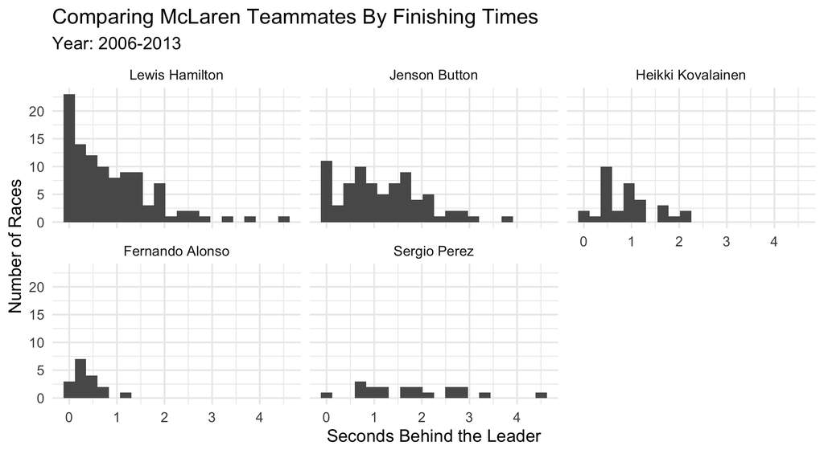

```r
fastest_lap_2007McLaren %>%
    ggplot() +
    geom_histogram(aes(x = secondsBehindLeader), bins = 20) +
    facet_wrap(~factor(name, levels = c('Lewis Hamilton', 'Jenson Button', 'Heikki Kovalainen', 'Fernando Alonso', 'Sergio Perez'))) +
    labs(x = "Seconds Behind the Leader",
         y = "Number of Races",
         title = "Comparing McLaren Teammates By Finishing Times",
         subtitle = "Year: 2006-2013") +
    theme_minimal()
```

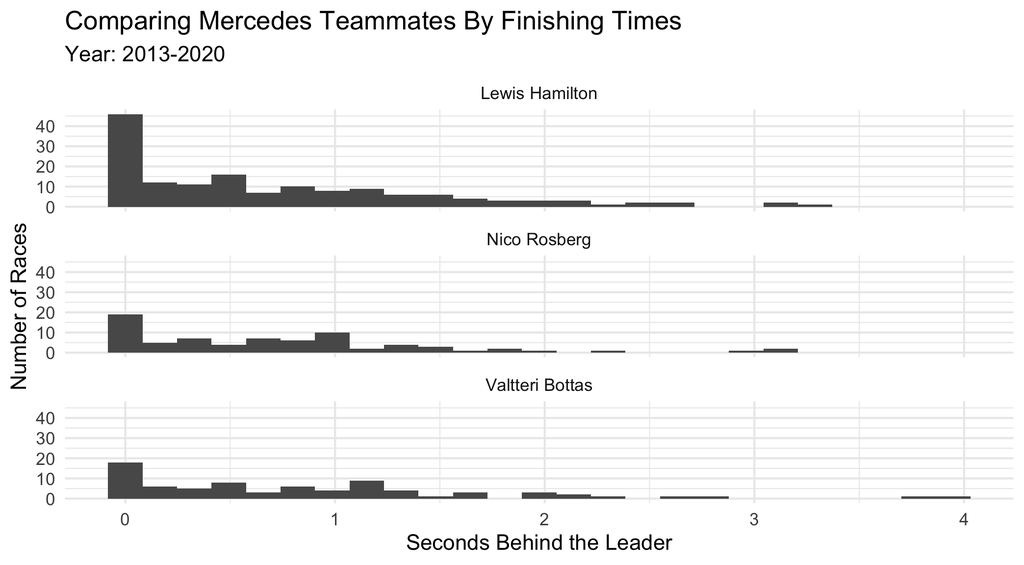

```r
fastest_lap_2013Mercedes %>%
    ggplot() +
    geom_histogram(aes(x = secondsBehindLeader), bins = 25) +
    facet_wrap(vars(name), ncol = 1) +
    labs(x = "Seconds Behind the Leader",
         y = "Number of Races",
         title = "Comparing Mercedes Teammates By Finishing Times",
         subtitle = "Year: 2013-2020") +
    theme_minimal()
```